# Linear Model Selection and Regularization

# Quesiton 1

Consider the data **usexpense_data** in which we take Risk-Based Capital **RBC** as the response variable. A description of the data can be found in this link http://cas.uqam.ca/pub/R/web/CASdatasets-manual.pdf

Here is the set up for the data:

```r
#install.packages("CASdatasets", repos = "http://cas.uqam.ca/pub/R/", type="source")
library(CASdatasets)
data(usexpense)
usexpense_data <- usexpense[-c(1,2,3,4)]
head(usexpense_data)
```

|  | RBC | Expenses | StaffWage | AgentWage | LongLoss | ShortLoss | GWPpersonal | GWPcommercial | Assets | Cash | LiqRatio |
| --- | --- | --- | --- | --- | --- | --- | --- | --- | --- | --- | --- |
| 1 | 228184000 | 0.0008019802 | 84.40508 | 77.46100 | 0.0001873308 | 0.000000000 | 0.000000000 | 0.001375438 | 0.002949942 | 0.003258406 | 110.45661 |
| 2 | 1627708000 | 0.0044878635 | 81.56754 | 84.87802 | 0.0027822909 | 0.000000000 | 0.000000000 | 0.012272512 | 0.022170349 | 0.019760347 | 89.12961 |
| 3 | 422907000 | 0.0019045075 | 84.40508 | 77.46100 | 0.0010121463 | 0.001329539 | 0.000000000 | 0.005028351 | 0.004617343 | 0.003499702 | 75.79472 |
| 4 | 652906000 | 0.0022909382 | 82.49788 | 75.71071 | 0.0000000000 | 0.002979557 | 0.029545038 | 0.001986159 | 0.043719914 | 0.040934885 | 93.62984 |
| 5 | 8124624000 | 0.0182956574 | 79.26495 | 78.24790 | 0.0107939577 | 0.011777314 | 0.040614120 | 0.058094479 | 0.144773034 | 0.138424153 | 95.61460 |
| 6 | 1441725000 | 0.0049830133 | 84.35856 | 77.41831 | 0.0019387476 | 0.003797946 | 0.001448431 | 0.013375740 | 0.029204831 | 0.029965958 | 102.60617 |

## (a) Omit all the **NA** rows in the data and keep the data under the same name **usexpense_data**

```r
usexpense_data=na.omit(usexpense_data)
```

## (b) Write the independent variables in a model matrix form, call it **x** and the response as a vector, call it **y** for the data **usexpense_data**.

```r
x=model.matrix(RBC~.,usexpense_data)[,-1]
y=usexpense_data$RBC
```

## (c) Set a seed of $123$ and split the data into a training set and a test set. The training set will contain $80\%$ of the data points, and the test set will include the remaining observations.

```r
## 80% of the sample size
## set the seed to make your partition reproducible
set.seed(123)
sample_size <- floor(0.80 * nrow(usexpense_data))
train=sample(1:nrow(usexpense_data),sample_size,replace=FALSE)
```

## (d) ) Using **glmnet** package, fit a ridge regression model on the training set, where the tuning parameter $\lambda$ is chosen by 10 folds cross-validation. Report the test error, call it **ridge.mse**, obtained and store ridge coefficients, call it **ridge.coef**. Plot the tuning parameters $\lambda$ versus cross-validation error.

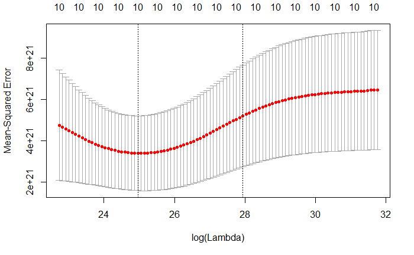

```r
#Find the optimal lambda value via cross validation
library(glmnet)
cv.out=cv.glmnet(x[train,],y[train],alpha=0, nfolds = 10, family="gaussian", type.measure="mse", standardize=TRUE)
bestlam=cv.out$lambda.min
plot(cv.out)
```

```r
#Fit a ridge regression model
ridge.mod=glmnet(x,y,alpha = 0, lambda=bestlam, family="gaussian")
#Compute the test error w/ lambda chosen by cross validation
ridge.pred=predict(ridge.mod,s=bestlam,newx=x[-train,])
ridge.mse=round(mean((ridge.pred-y[-train])^2))
#Store ridge coefficients
ridge.coef=predict(ridge.mod,type="coefficients",s=bestlam)
ridge.coef
```

```
11 x 1 sparse Matrix of class "dgCMatrix"
                        1
(Intercept)    -629006306
Expenses      49282593404
StaffWage       159498468
AgentWage       -59970666
LongLoss      22764592281
ShortLoss     34562754971
GWPpersonal   -5765845663
GWPcommercial 33449734098
Assets        13269810213
Cash          11879936791
LiqRatio        -33846942
```

## (e) Using **glmnet** package, fit a lasso regression model on the training set with $\lambda$ chosen by 10 folds cross-validation. Report the test error, call it **lasso.mse**, obtained and store lasso coefficients, call it **lasso.coef**. Plot the tuning parameters $\lambda$ versus cross-validation error.

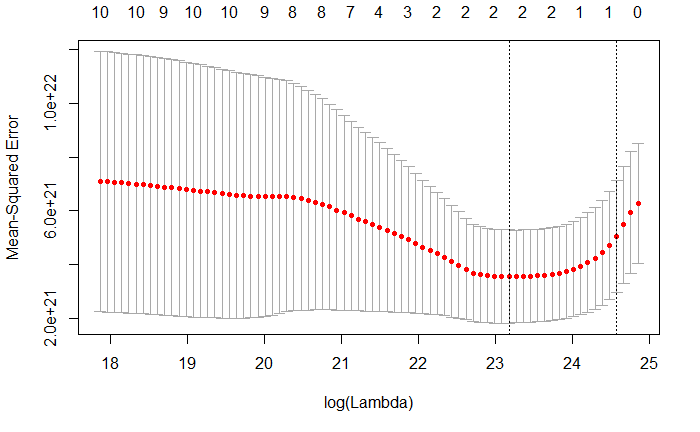

```r
#Find the optimal lambda value via cross validation
cv.out=cv.glmnet(x[train,],y[train],alpha=1, nfolds = 10, family="gaussian",type.measure="mse", standardize=TRUE)
bestlam=cv.out$lambda.min
plot(cv.out)
```

```r
#Train the model
lasso.mod=glmnet(x,y,alpha = 1, lambda=bestlam, family="gaussian")
#Compute the test error
lasso.pred=predict(lasso.mod,s=bestlam,newx=x[-train,])
lasso.mse=round(mean((lasso.pred-y[-train])^2))
#Store lasso coefficients
lasso.coef=predict(lasso.mod,type="coefficients",s=bestlam)
lasso.coef
```

```
11 x 1 sparse Matrix of class "dgCMatrix"
                        1
(Intercept)    5666149941
Expenses                .
StaffWage               .
AgentWage               .
LongLoss                .
ShortLoss               .
GWPpersonal             .
GWPcommercial 21506851254
Assets        38408596348
Cash                    .
LiqRatio                .
```

## (f) Using **glmnet** package, fit an elastic net regression model on the training set with $\lambda$ chosen by 10 folds cross-validation. Report the test error, call it **enet.mse**, obtained and store elastic net coefficients, call it **enet.coef**. Plot the tuning parameters $\lambda$ versus cross-validation error.

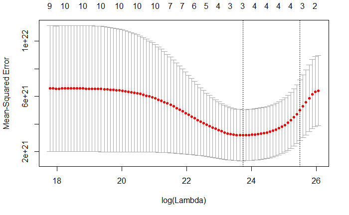

```r
#Find the optimal lambda value via cross validation
cv.out=cv.glmnet(x[train,],y[train],alpha=0.3, nfolds = 10, family="gaussian",type.measure="mse", standardize=TRUE)
bestlam=cv.out$lambda.min
plot(cv.out)
```

```r
#Train the model
enet.mod=glmnet(x,y,alpha = 0.3, lambda=bestlam, family="gaussian")
#Compute the test error
enet.pred=predict(enet.mod,s=bestlam,newx=x[-train,])
enet.mse=round(mean((enet.pred-y[-train])^2))
#Store elastic net coefficients
enet.coef=predict(enet.mod,type="coefficients",s=bestlam)
enet.coef
```

```
11 x 1 sparse Matrix of class "dgCMatrix"
                        1
(Intercept)    4610762869
Expenses                .
StaffWage               .
AgentWage               .
LongLoss                .
ShortLoss               .
GWPpersonal             .
GWPcommercial 44614010622
Assets        21718293495
Cash          12294493719
LiqRatio                .
```

## (g) Creat a data frame that includes the coefficients of ridge, lasso and elastic net along with the error term of each one of them.

```r
coefs=cbind(as.vector(ridge.coef),as.vector(lasso.coef),as.vector(enet.coef))
colnames(coefs)=c("ridge","lasso", "enet")
mse <- c(ridge.mse, lasso.mse, enet.mse)
rbind(coefs,mse)
```

```
            ridge        lasso         enet
    -6.290063e+08 5.666150e+09 4.610763e+09
     4.928259e+10 0.000000e+00 0.000000e+00
     1.594985e+08 0.000000e+00 0.000000e+00
    -5.997067e+07 0.000000e+00 0.000000e+00
     2.276459e+10 0.000000e+00 0.000000e+00
     3.456275e+10 0.000000e+00 0.000000e+00
    -5.765846e+09 0.000000e+00 0.000000e+00
     3.344973e+10 2.150685e+10 4.461401e+10
     1.326981e+10 3.840860e+10 2.171829e+10
     1.187994e+10 0.000000e+00 1.229449e+10
    -3.384694e+07 0.000000e+00 0.000000e+00
mse  1.626640e+20 1.714300e+20 1.518077e+20
```

# Quesiton 2

Consider the data **hurricanehist** that can be loaded through the **CASdatasets** package. A description of that data can be found in this link http://cas.uqam.ca/pub/R/web/CASdatasets-manual.pdf

The response variable **Region** is a multinomial variable that shows the region of the Hurricane. The goal of the study is to build a model that correctly classifies the storm maximum wind speeds based on the region. Fit a logistic regression model.

Here is the set up for the data :

```r
library(CASdatasets)
data(hurricanehist)
head(hurricanehist)
```

|  | Year | Region | Windmax | NAO | SOI | SST | SSTmda | sun |
| --- | --- | --- | --- | --- | --- | --- | --- | --- |
| 1 | 1899 | Basin | 96.64138 | -0.64 | -0.21 | 0.05193367 | -0.03133333 | 8.4 |
| 2 | 1899 | East | 90.19791 | -0.64 | -0.21 | 0.05193367 | -0.03133333 | 8.4 |
| 3 | 1899 | Basin | 90.35300 | -0.64 | -0.21 | 0.05193367 | -0.03133333 | 8.4 |
| 4 | 1899 | East | 37.51933 | -0.64 | -0.21 | 0.05193367 | -0.03133333 | 8.4 |
| 5 | 1899 | Basin | 51.06743 | -0.64 | -0.21 | 0.05193367 | -0.03133333 | 8.4 |
| 6 | 1899 | Basin | 40.00000 | -0.64 | -0.21 | 0.05193367 | -0.03133333 | 8.4 |

```r
hurricanehist_data= hurricanehist[-1]
```

## (a) Omit all the **NA** rows in the data and keep the data under the same name **hurricanehist_data**

```r
hurricanehist_data=na.omit(hurricanehist_data)
```

## (b) Write the independent variables in a model matrix form , call it **x** and the response as a vector, call it **y** for the data **hurricanehist_data**.

```r
x=model.matrix(Region ~.,hurricanehist_data)[,-1];
y=as.factor(hurricanehist_data$Region)
```

## (c) Set a seed of $123$ and split the data into a training set and a test set. The training set will contain $50\%$ of the data points, and the test set will include the remaining observations.

```r
set.seed(123)
sample_size <- floor(0.50 * nrow(hurricanehist_data))
train=sample(1:nrow(hurricanehist_data),sample_size,replace=FALSE)
```

## (d) Using **glmnet** package, fit a ridge logistic model on the training set, where the tuning parameter $\lambda$ is chosen by 10 folds cross-validation. Report ridge coefficients, call it **ridge.coef**.

```r
#Find the optimal lambda value via cross validation
cv.out=cv.glmnet(x[train,],y[train],alpha=0, nfolds = 10, family="multinomial", type.measure="class", standardize=TRUE)
bestlam=cv.out$lambda.min
#Fit a ridge regression model
ridge.mod=glmnet(x,y,alpha = 0, lambda=bestlam, family="multinomial")
#Compute the test error w/ lambda chosen by cross validation
ridge.pred=predict(ridge.mod,s=bestlam,newx=x[-train,])
#Store ridge coefficients
ridge.coef=predict(ridge.mod,type="coefficients",s=bestlam)
ridge.coef
```

```
$Basin
7 x 1 sparse Matrix of class "dgCMatrix"
                        1
(Intercept)  0.3843880964
Windmax      0.0105752992
NAO          0.0025102953
SOI          0.0019781060
SST         -0.1507322139
SSTmda       0.3779549728
sun          0.0006498236

$East
7 x 1 sparse Matrix of class "dgCMatrix"
                       1
(Intercept)  0.316065488
Windmax     -0.010519116
NAO          0.037573500
SOI          0.025799259
SST         -0.149352561
SSTmda       0.103096026
sun         -0.001807448

$Florida
7 x 1 sparse Matrix of class "dgCMatrix"
                        1
(Intercept) -0.0221354449
Windmax     -0.0045007826
NAO         -0.0596778945
SOI         -0.0002618955
SST          0.0536421880
SSTmda      -0.0779400187
sun         -0.0006072711

$Gulf
7 x 1 sparse Matrix of class "dgCMatrix"
                       1
(Intercept) -0.877941027
Windmax      0.002602391
NAO          0.016302504
SOI         -0.047450700
SST          0.149135096
SSTmda      -0.246947258
sun          0.001716409

$US
7 x 1 sparse Matrix of class "dgCMatrix"
                        1
(Intercept)  1.996229e-01
Windmax      1.842208e-03
NAO          3.291595e-03
SOI          1.993523e-02
SST          9.730749e-02
SSTmda      -1.561637e-01
sun          4.848634e-05
```

## (e) Using **glmnet** package, fit a lasso logistic model on the training set with $\lambda$ chosen by 10 folds cross-validation. Report the lasso coefficients, call it **lasso.coef**.

```r
#Find the optimal lambda value via cross validation
cv.out=cv.glmnet(x[train,],y[train],alpha=1, nfolds = 10, family="multinomial",type.measure="class", standardize=TRUE)
bestlam=cv.out$lambda.min
#Train the model
lasso.mod=glmnet(x,y,alpha = 1, lambda=bestlam, family="multinomial")
#Compute the test error
lasso.pred=predict(lasso.mod,s=bestlam,newx=x[-train,])
#Store lasso coefficients
lasso.coef=predict(lasso.mod,type="coefficients",s=bestlam)
lasso.coef
```

```
$Basin
7 x 1 sparse Matrix of class "dgCMatrix"
                      1
(Intercept) 0.375951327
Windmax     0.008942698
NAO         .
SOI         .
SST         .
SSTmda      0.313388556
sun         0.000303588

$East
7 x 1 sparse Matrix of class "dgCMatrix"
                       1
(Intercept)  0.346315478
Windmax     -0.013978211
NAO          .
SOI          .
SST          .
SSTmda       .
sun         -0.001203883

$Florida
7 x 1 sparse Matrix of class "dgCMatrix"
                       1
(Intercept) -0.113452888
Windmax     -0.005464798
NAO         -0.030998600
SOI          .
SST          .
SSTmda       .
sun          .

$Gulf
7 x 1 sparse Matrix of class "dgCMatrix"
                        1
(Intercept) -0.7926006328
Windmax      .
NAO          .
SOI          .
SST          .
SSTmda       .
sun          0.0008855124

$US
7 x 1 sparse Matrix of class "dgCMatrix"
                    1
(Intercept) 0.1837867
Windmax     .
NAO         .
SOI         .
SST         .
SSTmda      .
sun         .
```

## (f) Using **glmnet** package, fit an elastic net logistic regression model on the training set with $\lambda$ chosen by 10 folds cross-validation. Report the elastic coefficients, call it **enet.coef**.

```r
#Find the optimal lambda value via cross validation
cv.out=cv.glmnet(x[train,],y[train],alpha=0.3, nfolds = 10, family="multinomial",type.measure="class", standardize=TRUE)
bestlam=cv.out$lambda.min
#Train the model
enet.mod=glmnet(x,y,alpha = 0.3, lambda=bestlam, family="multinomial")
#Compute the test error
enet.pred=predict(enet.mod,s=bestlam,newx=x[-train,])
#Store lasso coefficients
enet.coef=predict(enet.mod,type="coefficients",s=bestlam)
enet.coef
```

```
$Basin
7 x 1 sparse Matrix of class "dgCMatrix"
                        1
(Intercept)  0.3123600686
Windmax      0.0091299366
NAO          .
SOI          .
SST         -0.2697235489
SSTmda       0.5288663380
sun          0.0005924604

$East
7 x 1 sparse Matrix of class "dgCMatrix"
                       1
(Intercept)  0.498262439
Windmax     -0.015932219
NAO          0.029832905
SOI          0.022902401
SST         -0.106045965
SSTmda       0.112401196
sun         -0.002187248

$Florida
7 x 1 sparse Matrix of class "dgCMatrix"
                       1
(Intercept) -0.011317621
Windmax     -0.007251633
NAO         -0.066696895
SOI          .
SST          .
SSTmda       .
sun         -0.000593044

$Gulf
7 x 1 sparse Matrix of class "dgCMatrix"
                       1
(Intercept) -0.956791190
Windmax      0.001006077
NAO          0.001101244
SOI         -0.053077279
SST          0.090695965
SSTmda      -0.188450468
sun          0.001927557

$US
7 x 1 sparse Matrix of class "dgCMatrix"
                      1
(Intercept)  0.15748630
Windmax      .
NAO          .
SOI          0.01179490
SST          .
SSTmda      -0.03555223
sun          .
```

# Question 3

Consider the data **fremotor1prem_data** in which we take the total premium **PremTot** as the response variable. A description of the data can be found in this link http://cas.uqam.ca/pub/R/web/CASdatasets-manual.pdf

Here is the set up of the data:

```r
library(CASdatasets)
data(fremotor1prem)
head(fremotor1prem)
```

|  | IDpol | DrivAge | DrivGender | MaritalStatus | BonusMalus | LicenceNb | VehNb | PayFreq | JobCode | VehAge | VehClass | VehPower | VehGas | VehUsage | Garage | Area | Region | Channel | Marketing | PremWindscreen | PremDamAll | PremFire | PremAcc1 | PremAcc2 | PremLegal | PremTPLM | PremTPLV | PremServ | PremTheft | … |
| --- | --- | --- | --- | --- | --- | --- | --- | --- | --- | --- | --- | --- | --- | --- | --- | --- | --- | --- | --- | --- | --- | --- | --- | --- | --- | --- | --- | --- | --- | --- |
| 1 | 1000111.100 | 44 | F | Cohabiting | 50 | 3 | 3 | Half-yearly | Private employee | 10 | Cheaper | P10 | Regular | Private+trip to office | Closed zbox | A2 | Headquarters | A | M1 | 15 | 0 | 0 | 0 | 0 | 6 | 69.1 | 4 | 50 | 0 | … |
| 2 | 1000111.100 | 44 | F | Cohabiting | 50 | 3 | 3 | Half-yearly | Private employee | 10 | Cheaper | P10 | Regular | Private+trip to office | Closed zbox | A2 | Headquarters | A | M1 | 16 | 0 | 0 | 0 | 0 | 7 | 75.3 | 4 | 55 | 0 | … |
| 3 | 1000113.100 | 27 | F | Cohabiting | 106 | 2 | 2 | Half-yearly | Other | 6 | Cheaper | P11 | Regular | Private+trip to office | Opened collective parking | A7 | Headquarters | A | M2 | 60 | 0 | 0 | 0 | 0 | 17 | 453.6 | 24 | 57 | 0 | … |
| 4 | 1000113.100 | 27 | F | Cohabiting | 106 | 2 | 2 | Half-yearly | Other | 6 | Cheaper | P11 | Regular | Private+trip to office | Opened collective parking | A7 | Headquarters | A | M2 | 65 | 0 | 0 | 0 | 0 | 19 | 494.4 | 26 | 62 | 0 | … |
| 5 | 1000113.100 | 26 | F | Cohabiting | 85 | 2 | 2 | Annual | Other | 8 | Cheapest | P8 | Regular | Private+trip to office | Opened collective parking | A7 | Headquarters | A | M2 | 16 | 0 | 0 | 0 | 0 | 7 | 139.3 | 7 | 46 | 0 | … |
| 6 | 1000113.100 | 26 | F | Cohabiting | 85 | 2 | 2 | Half-yearly | Other | 8 | Cheapest | P8 | Regular | Private+trip to office | Opened collective parking | A7 | Headquarters | A | M2 | 19 | 0 | 0 | 0 | 0 | 8 | 168.5 | 9 | 56 | 0 | … |

```r
fremotor1prem_data <- fremotor1prem[-c(1,31)]
```

```r
fremotor1prem_data=na.omit(fremotor1prem_data)
```

## (b) Write the independent variables in a model matrix form, call it **x** and the response as a vector, call it **y** for the data **fremotor1prem_data**.

```r
x=model.matrix(PremTot ~.,fremotor1prem_data)[,-1]
y=fremotor1prem_data$PremTot
```

## (c) Set a seed of $123$ and split the data into a training set and a test set. The training set will contain $70\%$ of the data points, and the test set will include the remaining observations.

```r
set.seed(123)
sample_size <- floor(0.70 * nrow(fremotor1prem_data))
train=sample(1:nrow(fremotor1prem_data),sample_size,replace=FALSE)
```

## (d) Using **glmnet** package, fit an elastic net regression model on the training set, where the tuning parameter $\lambda$ is chosen by 10 folds cross-validation. Choose the Elastic net mixing parameter i.e $\alpha$ that obtain the smallest MSE. Remember that Elastic net takes $\alpha$ values greater than $0$ and less than $1$ exclusive. Show how you obtained that $\alpha$.

```r
for (i in seq(0, 1, .1)){
    enet.mse <- data.frame()
    #Using cross-validation to choose the tuning parameter ??
    set.seed (123)
    cv.out=cv.glmnet(x[train,],y[train],alpha=i, nfolds = 10,
                          family="gaussian",type.measure="mse", standardize=TRUE)
    bestlam=cv.out$lambda.min
    #Creating training model using lasso regression
    enet.mod=glmnet(x,y,alpha = i, lambda=bestlam, family="gaussian")
    #Printing out
    #Compute the test error
    enet.pred=predict(enet.mod,s=bestlam,newx=x[-train,])
    enet.mse=mean((enet.pred-y[-train])^2)
    print(c(enet.mse,i))

}
```

```
[1] 210.5297   0.0000
[1] 50.25861  0.10000
[1] 52.17949  0.20000
[1] 51.90291  0.30000
[1] 47.94492  0.40000
[1] 50.02046  0.50000
[1] 47.61418  0.60000
[1] 49.70887  0.70000
[1] 54.15452  0.80000
[1] 50.70077  0.90000
[1] 48.65152  1.00000
```

# Question 4

Consider the data “wholesale-customers.csv”. This dataset refers to clients of a wholesale distributor. It includes the annual spending in monetary units (m.u.) on diverse product categories.

It is part of a larger database published with the following paper:

Abreu, N. (2011). Analise do perfil do cliente Recheio e desenvolvimento de um sistema promocional. Mestrado em Marketing, ISCTE-IUL, Lisbon.

The data consists of annual spending on different categories of products by each retailer, along with corresponding data on the sales channel (Hotel/Restaurant/Cafe = 1 vs. Retail = 2) and the region (Lisbon = 1, Oporto = 2, or Other = 3) of the retailer.

Fit logistic lasso and elastic net regression to identify the coefficients that use spending on different categories of products to predict the sales channel. Split randomly the data into a training set and a test set. The training set will contain $70\%$ of the data points and the test set will contain the remaining observations. Set a seed of $123$ to make your partition reproducible.

## (a) Choose the tuning parameters $\lambda$ using 10 folds cross-validation. Include plot of tuning parameters versus cross-validation error.

```r
library(glmnet)
wholesale_data <- read.csv("wholesale_customers.csv", header=TRUE, sep=",")
wholesale_data=na.omit(wholesale_data)
head(wholesale_data)
```

|  | Channel | Region | Fresh | Milk | Grocery | Frozen | Detergents_Paper | Delicassen |
| --- | --- | --- | --- | --- | --- | --- | --- | --- |
| 1 | 2 | 3 | 12669 | 9656 | 7561 | 214 | 2674 | 1338 |
| 2 | 2 | 3 | 7057 | 9810 | 9568 | 1762 | 3293 | 1776 |
| 3 | 2 | 3 | 6353 | 8808 | 7684 | 2405 | 3516 | 7844 |
| 4 | 1 | 3 | 13265 | 1196 | 4221 | 6404 | 507 | 1788 |
| 5 | 2 | 3 | 22615 | 5410 | 7198 | 3915 | 1777 | 5185 |
| 6 | 2 | 3 | 9413 | 8259 | 5126 | 666 | 1795 | 1451 |

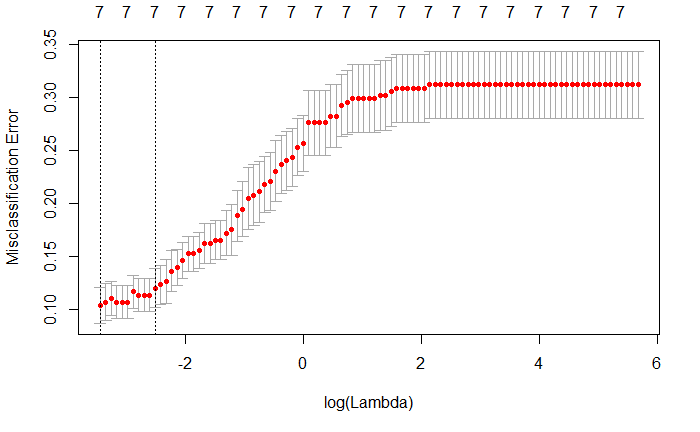

```r
x=model.matrix(Channel ~.,wholesale_data)[,-1];
y=as.factor(wholesale_data$Channel)

set.seed(123)
sample_size <- floor(0.70 * nrow(wholesale_data))
train=sample(1:nrow(wholesale_data),sample_size,replace=FALSE)
cv.out=cv.glmnet(x[train,],y[train],alpha=0, nfolds = 10, family="binomial", type.measure="class", standardize=TRUE)
plot(cv.out)
```

```r
bestlam=cv.out$lambda.min
bestlam
```

```
[1] 0.0319796
```

## (b) Include the coefficients computed.

```r
#Find the optimal lambda value via cross validation
cv.out=cv.glmnet(x[train,],y[train],alpha=1, nfolds = 10, family="multinomial",type.measure="class", standardize=TRUE)
bestlam=cv.out$lambda.min
#Train the model
lasso.mod=glmnet(x,y,alpha = 1, lambda=bestlam, family="binomial")
#Compute the test error
lasso.pred=predict(lasso.mod,s=bestlam,newx=x[-train,])
#Store lasso coefficients
lasso.coef=predict(lasso.mod,type="coefficients",s=bestlam)
lasso.coef
```

```
8 x 1 sparse Matrix of class "dgCMatrix"
                             1
(Intercept)      -4.642103e+00
Region            3.915772e-01
Fresh             1.133325e-06
Milk              7.126906e-05
Grocery           1.101830e-04
Frozen           -1.407286e-04
Detergents_Paper  8.371478e-04
Delicassen       -6.000086e-05
```

```r
#Find the optimal lambda value via cross validation
cv.out=cv.glmnet(x[train,],y[train],alpha=0.3, nfolds = 10, family="multinomial",type.measure="class", standardize=TRUE)
bestlam=cv.out$lambda.min
#Train the model
enet.mod=glmnet(x,y,alpha = 0.3, lambda=bestlam, family="multinomial")
#Compute the test error
enet.pred=predict(enet.mod,s=bestlam,newx=x[-train,])
#Store lasso coefficients
enet.coef=predict(enet.mod,type="coefficients",s=bestlam)
enet.coef
```

```
$`1`
8 x 1 sparse Matrix of class "dgCMatrix"
                             1
(Intercept)       2.199684e+00
Region           -1.792344e-01
Fresh             .
Milk             -3.592975e-05
Grocery          -6.208218e-05
Frozen            7.099140e-05
Detergents_Paper -3.643050e-04
Delicassen        2.791269e-05

$`2`
8 x 1 sparse Matrix of class "dgCMatrix"
                             1
(Intercept)      -2.199684e+00
Region            1.792344e-01
Fresh             .
Milk              3.592975e-05
Grocery           6.208218e-05
Frozen           -7.099140e-05
Detergents_Paper  3.643050e-04
Delicassen       -2.791269e-05
```

# Question 5

In matrix terms, the initial quadratic loss function becomes
$$\begin{equation}
\min_\beta (Y-\beta^T X)^T(Y-\beta^T X)+\lambda \beta^T \beta
\end{equation}$$
Now note that
$$\begin{equation}
\frac{\partial (Y-\beta^T X)^T (Y-\beta^T X)}{\partial \beta}=-2X^T(Y-\beta^T X)
\end{equation}$$
and
$$\begin{equation}
\frac{\partial \lambda \beta^T \beta}{\partial \beta}=2\lambda\beta.
\end{equation}$$
Together we get to the first order condition
$$\begin{equation}
X^TY = X^TX\beta + \lambda\beta.
\end{equation}$$
Isolating $\beta$ yields the Ridge estimator, that is,
$$\begin{equation}
\hat{\beta}_{Ridge} = (X^TX+ \lambda I )^{-1}X^T Y.
\end{equation}$$
Now, consider the data below **eqlist_data** in which the magnitude **mag** is taking as the response variable. Omit all the **NA** rows, if any. Description of the data can be found in this link http://cas.uqam.ca/pub/R/web/CASdatasets-manual.pdf

Here is the set up of that data:

```r
library(CASdatasets)
data(eqlist)
head(eqlist)
```

|  | time | latitude | longitude | depth | mag | magType | nst | gap | dmin | rms | net | id | updated | place | type | day |
| --- | --- | --- | --- | --- | --- | --- | --- | --- | --- | --- | --- | --- | --- | --- | --- | --- |
| 1 | 2014-03-05T09:56:58.630Z | -14.7347 | 169.8222 | 636.76 | 6.3 | mwp | NA | 29 | 7.970 | 0.83 | us | usb000n1ex | 2014-03-05T17:59:33.305Z | 262km ESE of Sola, Vanuatu | earthquake | 2014-03-05 |
| 2 | 2014-03-02T20:11:22.640Z | 27.4052 | 127.3354 | 111.18 | 6.5 | mwc | NA | 26 | 1.009 | 1.01 | us | usb000mzmn | 2014-03-06T09:06:38.195Z | 110km NW of Nago, Japan | earthquake | 2014-03-02 |
| 3 | 2014-03-02T09:37:56.210Z | 12.6286 | -87.6371 | 72.61 | 6.2 | mwc | NA | 22 | 1.322 | 1.15 | us | usb000mzef | 2014-03-05T06:11:36.329Z | 23km WSW of Jiquilillo, Nicaragua | earthquake | 2014-03-02 |
| 4 | 2014-02-26T21:13:40.600Z | 53.6792 | -171.8369 | 264.66 | 6.1 | mwb | NA | 43 | 1.923 | 0.78 | us | usc000myqq | 2014-03-02T21:09:15.040Z | 138km NNW of Amukta Island, Alaska | earthquake | 2014-02-26 |
| 5 | 2014-02-18T09:27:13.490Z | 14.6511 | -58.9478 | 16.86 | 6.5 | mww | NA | 30 | 1.611 | 0.94 | us | usc000mskt | 2014-02-22T00:17:38.773Z | 170km NNE of Bathsheba, Barbados | earthquake | 2014-02-18 |
| 6 | 2014-02-12T09:19:48.630Z | 35.9221 | 82.5485 | 10.00 | 6.9 | mww | NA | 23 | 7.465 | 1.36 | us | usc000mnvj | 2014-02-12T21:16:04.368Z | 268km ESE of Hotan, China | earthquake | 2014-02-12 |

```r
eqlist_data <- eqlist[-c(1,6,7,11:16)]
head(eqlist_data)
```

|  | latitude | longitude | depth | mag | gap | dmin | rms |
| --- | --- | --- | --- | --- | --- | --- | --- |
| 1 | -14.7347 | 169.8222 | 636.76 | 6.3 | 29 | 7.970 | 0.83 |
| 2 | 27.4052 | 127.3354 | 111.18 | 6.5 | 26 | 1.009 | 1.01 |
| 3 | 12.6286 | -87.6371 | 72.61 | 6.2 | 22 | 1.322 | 1.15 |
| 4 | 53.6792 | -171.8369 | 264.66 | 6.1 | 43 | 1.923 | 0.78 |
| 5 | 14.6511 | -58.9478 | 16.86 | 6.5 | 30 | 1.611 | 0.94 |
| 6 | 35.9221 | 82.5485 | 10.00 | 6.9 | 23 | 7.465 | 1.36 |

```r
eqlist_data=na.omit(eqlist_data)
```

Use the matrix format to write your own function **fitRidge** to estimate the coefficient for a Ridge regression i.e $\hat{\beta}_{Ridge}$ . Your function needs to take three parameters: $Y$ (response), $X$ (predictor), and $\lambda$ (tuning parameter). Choose $\lambda$ to be $0.10$.

```r
x=as.matrix(eqlist_data[-4])
y=as.vector(eqlist_data$mag)
fitRidge <- function(X, y, lambda){
  # Add intercept column to X:
  X <- cbind(1, X)
  # Calculate penalty matrix:
  lambda.diag <- lambda * diag(dim(X)[2])
  # Apply formula for Ridge Regression:
  return(solve(t(X) %*% X + lambda.diag)%*%t(X) %*% y)
  }
fitRidge(x,y,0.10)
```

```
                   [,1]
           6.0543110871
latitude   0.0015389275
longitude  0.0001219868
depth      0.0002245387
gap       -0.0042250086
dmin       0.0120012490
rms        0.3934989503
```

# Question 6

Use lasso regression to predict the total claim amount **ClaimAmount** based on a few of predictor measurements. This data set is taken from the **CASdatasets** package. Here is the set up for the data :

```r
library(CASdatasets)
data(swmotorcycle)
head(swmotorcycle)
```

|  | OwnerAge | Gender | Area | RiskClass | VehAge | BonusClass | Exposure | ClaimNb | ClaimAmount |
| --- | --- | --- | --- | --- | --- | --- | --- | --- | --- |
| 1 | 0 | Male | Central parts of Sweden's three largest cities | EV ratio 13-15 | 12 | BM1 | 0.175342 | 0 | 0 |
| 2 | 4 | Male | Lesser towns except Gotland; Northern towns | EV ratio 20-24 | 9 | BM1 | 0.000000 | 0 | 0 |
| 3 | 5 | Female | Lesser towns except Gotland; Northern towns | EV ratio 9-12 | 18 | BM1 | 0.454795 | 0 | 0 |
| 4 | 5 | Female | Small towns; countryside except Gotland; Northern towns | EV ratio <5 | 25 | BM1 | 0.172603 | 0 | 0 |
| 5 | 6 | Female | Suburbs; middle-sized cities | EV ratio <5 | 26 | BM1 | 0.180822 | 0 | 0 |
| 6 | 9 | Female | Lesser towns except Gotland; Northern towns | EV ratio 9-12 | 8 | BM1 | 0.542466 | 0 | 0 |

```r
swmotorcycle_data <- swmotorcycle[-c(3,4)]
head(swmotorcycle_data)
```

|  | OwnerAge | Gender | VehAge | BonusClass | Exposure | ClaimNb | ClaimAmount |
| --- | --- | --- | --- | --- | --- | --- | --- |
| 1 | 0 | Male | 12 | BM1 | 0.175342 | 0 | 0 |
| 2 | 4 | Male | 9 | BM1 | 0.000000 | 0 | 0 |
| 3 | 5 | Female | 18 | BM1 | 0.454795 | 0 | 0 |
| 4 | 5 | Female | 25 | BM1 | 0.172603 | 0 | 0 |
| 5 | 6 | Female | 26 | BM1 | 0.180822 | 0 | 0 |
| 6 | 9 | Female | 8 | BM1 | 0.542466 | 0 | 0 |

Omit all the **NA** rows, if any. Description of the data can be found in this link http://cas.uqam.ca/pub/R/web/CASdatasets-manual.pdf. Set a seed of $123$ and split the data into a training set and a test set. The training set will contain $70\%$ of the data points and the test set will contain the remaining observations.

Via 5-fold cross-validation you have computed $2$ values of the tuning parameter $\lambda$: $\lambda_{Ridge}$.min and $\lambda_{Ridge}$.1se. Using the usual rule (min) or the one standard error rule (1se) to select $\lambda$. Now, fit lasso regression once with $\lambda_{Ridge}$.min and then with $\lambda_{Ridge}$.1se. Report the coefficient estimates and the error at the appropriate values of $\lambda$. That is, you will report two coefficient vectors coming from ridge regression with $\lambda = \lambda$ ridge min and $\lambda = \lambda$ ridge 1se. Comment on the results?

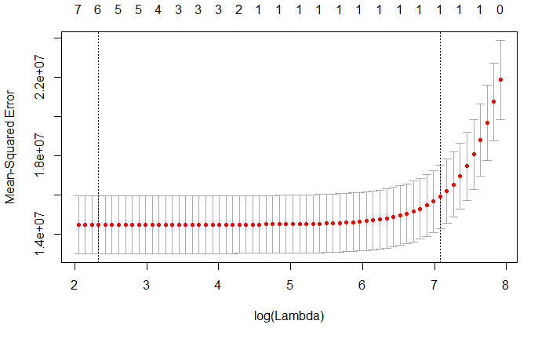

```r
swmotorcycle_data=na.omit(swmotorcycle_data)
x=model.matrix(ClaimAmount ~.,swmotorcycle_data)[,-1]
y=swmotorcycle_data$ClaimAmount
## set the seed to make your partition reproducible
##80% of the sample size
set.seed(123)
sample_size <- floor(0.70 * nrow(swmotorcycle_data))
train=sample(1:nrow(swmotorcycle_data),sample_size,replace=FALSE)
#Find the optimal lambda value via cross validation using
cv.out=cv.glmnet(x[train,],y[train],alpha=1, nfolds = 5, family="gaussian",type.measure="mse", standardize=TRUE)
bestlam_lambda.min=cv.out$lambda.min
plot(cv.out)
```

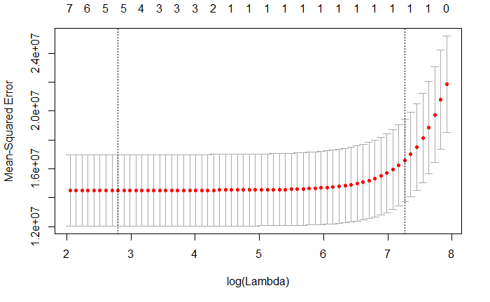

```r
#Train the model
lasso.mod=glmnet(x,y,alpha = 1, lambda=bestlam_lambda.min, family="gaussian")
#Compute the test error
lasso.pred=predict(lasso.mod,s=bestlam_lambda.min,newx=x[-train,])
lasso.mse.lambda.min=round(mean((lasso.pred-y[-train])^2))
#Store lasso coefficients
lasso.coef.lambda.min=predict(lasso.mod,type="coefficients",s=bestlam_lambda.min)
lasso.coef.lambda.min=round(lasso.coef.lambda.min,6)
#Find the optimal lambda value via cross validation using
cv.out=cv.glmnet(x[train,],y[train],alpha=1, nfolds = 5, family="gaussian",type.measure="mse", standardize=TRUE)
bestlam_lambda.1se=cv.out$lambda.1se
plot(cv.out)
```

```r
#Train the model
lasso.mod=glmnet(x,y,alpha = 1, lambda=bestlam_lambda.1se, family="gaussian")
#Compute the test error
lasso.pred=predict(lasso.mod,s=bestlam_lambda.1se,newx=x[-train,])
lasso.mse.lambda.1se=round(mean((lasso.pred-y[-train])^2))
#Store lasso coefficients
lasso.coef.lambda.1se=predict(lasso.mod,type="coefficients",s=bestlam_lambda.1se)
lasso.coef.lambda.1se=round(lasso.coef.lambda.1se,6)
coefs=cbind(as.vector(lasso.coef.lambda.min),as.vector(lasso.coef.lambda.1se))
colnames(coefs)=c("lasso.min.lambda", "lasso.1st.lambda")
mse <- c(lasso.mse.lambda.min, lasso.mse.lambda.1se)
rbind(coefs,mse)
```

```
    lasso.min.lambda lasso.1st.lambda
        6.072553e+01     1.307899e+02
        0.000000e+00     0.000000e+00
        2.112730e+01     0.000000e+00
       -6.165875e+00     0.000000e+00
        0.000000e+00     0.000000e+00
        1.596617e+01     0.000000e+00
        7.800123e+00     0.000000e+00
        0.000000e+00     0.000000e+00
        6.776605e+00     0.000000e+00
       -2.589529e+01     0.000000e+00
       -8.507735e+00     0.000000e+00
        2.551930e+04     1.233801e+04
mse     1.442449e+07     1.648492e+07
```

# Question 7

The multiresponse Gaussian (normal) family is obtained using **family = “mgaussian”** option in **glmnet**. It is very similar to the single-response case **family = “gaussian”**, which is the default choice in **glmnet**. This can be useful when there are a number of (correlated) responses.

Now, consider Canadian life insurance data **canlifins**. So, you have a matrix **y** consist of two columns **EntryAgeM** and ** EntryAgeF** (response) and the rest of the variables are your **x** matrix (explanatory variables). This data set is taken from the **CASdatasets** package.

Fit a multi-response Gaussian model, using ridge, lasso, and elastic net penalty. Obtain the estimated coefficients of each model.

```r
library(CASdatasets)
data(canlifins)
head(canlifins)
```

|  | EntryAgeM | EntryAgeF | DeathTimeM | DeathTimeF | AnnuityExpiredM |
| --- | --- | --- | --- | --- | --- |
| 1 | 60.6749 | 62.1217 | 0 | 0 | 5.0055 |
| 2 | 69.1463 | 68.4249 | 0 | 0 | 5.0055 |
| 3 | 66.1612 | 64.9973 | 0 | 0 | 1.6655 |
| 4 | 58.0751 | 60.0039 | 0 | 0 | 1.6655 |
| 5 | 70.5779 | 65.0532 | 0 | 0 | 3.1655 |
| 6 | 67.8756 | 64.8920 | 0 | 0 | 3.2488 |

```r
canlifins_data <- canlifins
head(canlifins_data)
```

|  | EntryAgeM | EntryAgeF | DeathTimeM | DeathTimeF | AnnuityExpiredM |
| --- | --- | --- | --- | --- | --- |
| 1 | 60.6749 | 62.1217 | 0 | 0 | 5.0055 |
| 2 | 69.1463 | 68.4249 | 0 | 0 | 5.0055 |
| 3 | 66.1612 | 64.9973 | 0 | 0 | 1.6655 |
| 4 | 58.0751 | 60.0039 | 0 | 0 | 1.6655 |
| 5 | 70.5779 | 65.0532 | 0 | 0 | 3.1655 |
| 6 | 67.8756 | 64.8920 | 0 | 0 | 3.2488 |

```r
canlifins_data$DeathTimeF
```

[output not shown]

[output cut: 77 more lines]

```r
canlifins_data=na.omit(canlifins_data)
x=as.matrix(canlifins_data[-c(1,2)]);x
```

[output not shown]

[output cut: 320 more lines]

```r
y=as.matrix(canlifins_data[-c(3,4,5)]);y
```

[output not shown]

[output cut: 487 more lines]

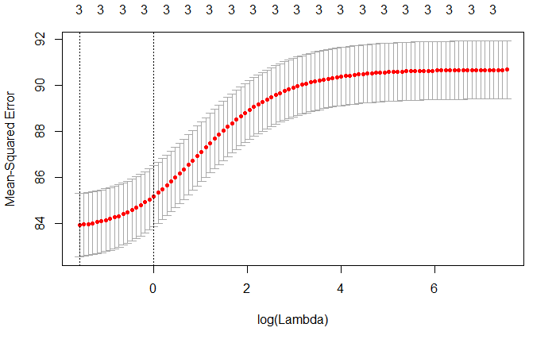

```r
#Find the optimal lambda value via cross validation
library(glmnet)
cv.out=cv.glmnet(x,y,alpha=0, nfolds = 10, family="mgaussian")
bestlam=cv.out$lambda.min
plot(cv.out)
```

```r
#Fit a ridge regression model
ridge.mod=glmnet(x,y,alpha = 0, lambda=bestlam, family="mgaussian")
#Compute the test error w/ lambda chosen by cross validation
ridge.pred=predict(ridge.mod,s=bestlam,newx=x[1:50,])
#Store ridge coefficients
ridge.coef=predict(ridge.mod, type="coefficients",s=bestlam)
ridge.coef
```

```
$EntryAgeM
4 x 1 sparse Matrix of class "dgCMatrix"
                         1
(Intercept)     63.6849495
DeathTimeM       1.0071380
DeathTimeF       0.9450883
AnnuityExpiredM  0.9085463

$EntryAgeF
4 x 1 sparse Matrix of class "dgCMatrix"
                         1
(Intercept)     60.6698519
DeathTimeM       0.9118520
DeathTimeF       1.2560650
AnnuityExpiredM  0.9373478
```

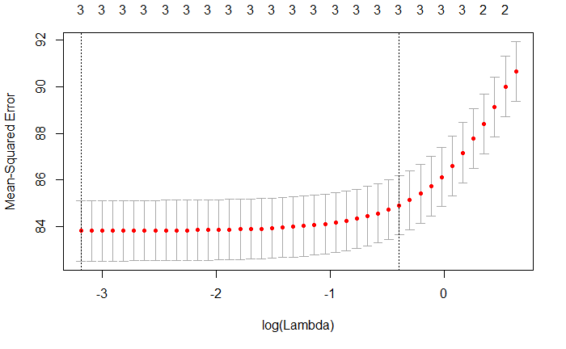

```r
#Find the optimal lambda value via cross validation
cv.out=cv.glmnet(x,y,alpha=1, nfolds = 10, family="mgaussian")
bestlam=cv.out$lambda.min
plot(cv.out)
```

```r
#Train the model
lasso.mod=glmnet(x,y,alpha = 1, lambda=bestlam, family="mgaussian")
#Compute the test error
lasso.pred=predict(lasso.mod,s=bestlam,newx=x[1:50,])
#Store lasso coefficients
lasso.coef=predict(lasso.mod,type="coefficients",s=bestlam)
lasso.coef
```

```
$EntryAgeM
4 x 1 sparse Matrix of class "dgCMatrix"
                        1
(Intercept)     63.000883
DeathTimeM       1.150198
DeathTimeF       1.039603
AnnuityExpiredM  1.051825

$EntryAgeF
4 x 1 sparse Matrix of class "dgCMatrix"
                        1
(Intercept)     59.963509
DeathTimeM       1.032470
DeathTimeF       1.404393
AnnuityExpiredM  1.085734
```

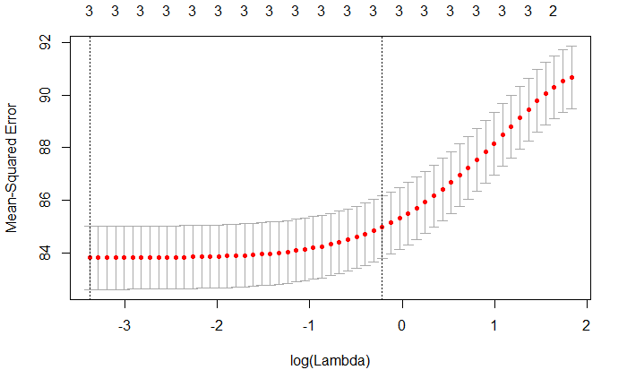

```r
#Find the optimal lambda value via cross validation
cv.out=cv.glmnet(x,y,alpha=0.3, nfolds = 10, family="mgaussian")
bestlam=cv.out$lambda.min
plot(cv.out)
```

```r
#Train the model
enet.mod=glmnet(x,y,alpha = 0.3, lambda=bestlam, family="mgaussian")
#Compute the test error
enet.pred=predict(enet.mod,s=bestlam,newx=x[1:50,])
#Store elastic net coefficients
enet.coef=predict(enet.mod,type="coefficients",s=bestlam)
enet.coef
```

```
$EntryAgeM
4 x 1 sparse Matrix of class "dgCMatrix"
                        1
(Intercept)     63.022273
DeathTimeM       1.148641
DeathTimeF       1.048297
AnnuityExpiredM  1.046920

$EntryAgeF
4 x 1 sparse Matrix of class "dgCMatrix"
                        1
(Intercept)     59.985724
DeathTimeM       1.030787
DeathTimeF       1.415845
AnnuityExpiredM  1.080590
```